# Homework3,uni:qh2174

Q1. Mosaic plots [10 points] Use a mosaic plot (or plots) to display the Punishment dataset in the vcd package. What patterns of association do you see between the conditioning (independent / explanatory) variables and the response (dependent) variable? Discuss single factor patterns as well as two and three factor interactions. Answer: This dataset studies about the attitude towards corporal punishment of children. A data frame with 36 observations and 5 variables. Freq: frequency. attitude: factor indicating attitude: (no, moderate) punishment of children. memory: factor indicating whether the person had memories of corporal punishment as a child (yes, no). education: factor indicating highest level of education (elementary, secondary, high). age: factor indicating age group in years (15-24, 25-39, 40-).

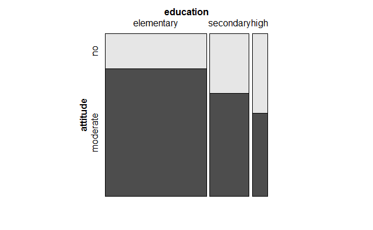

```r
data(Punishment, package="vcd")
vcd::mosaic(attitude ~ education, data = Punishment,direction = c("v", "h"))
```

From single relationship between attitude and education, we can see people with higher education are more likely to support no punishment on children.

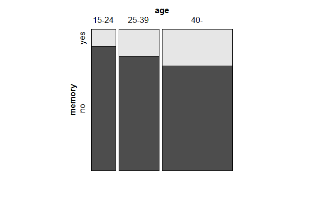

```r
data(Punishment, package="vcd")
vcd::mosaic(memory ~ age, data = Punishment,direction = c("v", "h"))
```

From single relationship between memory and age, we can see younger people are les likely to have punishment as a child, meaning now child punishment becomes less now.

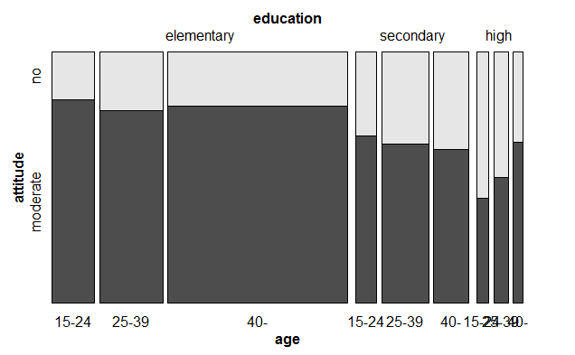

```r
vcd::mosaic(attitude ~ education + age, data = Punishment,direction = c("v", "v", "h"), highlighting_direction="down", highlighting_colot="red")
```

From graph, we can see that education have a major impact on the attitude towdars punishment.

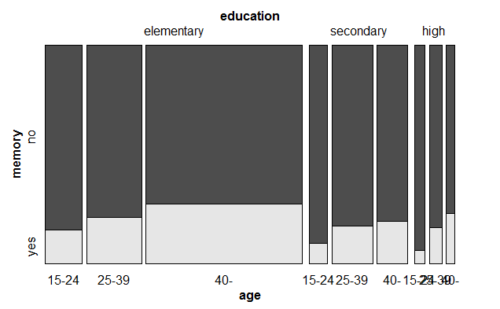

```r
vcd::mosaic(memory ~ education + age, data = Punishment,direction = c("v", "v", "h"), highlighting_direction="top")
```

From the above graph, we know that people with age 15-24 have few momery of punishment.

Q2: Heatmaps [20 points] Use heatmaps to explore the sample sales dataset “WA_Sales_Products_2012-14.csv” (88475 rows x 11 columns) found here: https://www.ibm.com/communities/analytics/watson-analytics-blog/sales-products-sample-data/ Include 3 heatmaps in your assignment and describe the patterns you found. Answer:

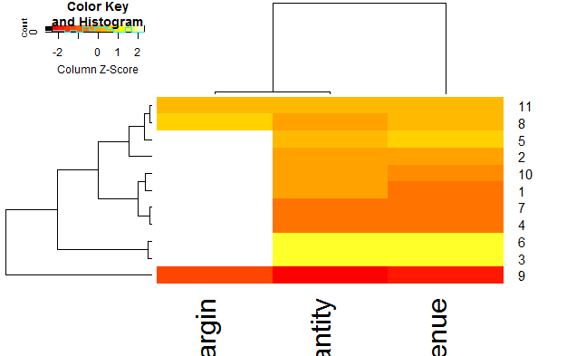

```r
library(gplots)
sales <- read.csv ("WA_Sales_Products_2012-14.csv")
df<-data.frame(sales$Quarter, sales$Revenue,sales$Quantity, sales$Gross.margin)
df_aggregate<-aggregate(df[,c(2,3,4)],list(df[,1]),sum)
colnames(df_aggregate) <- c("YearQuarter", "Revenue", "Quantity", "Gross.margin")
df_aggregate_del<-df_aggregate[,c(2,3,4)]
heatmap.2(as.matrix(df_aggregate_del), scale="column", trace="none")
```

We can see there’s some data missing for Gross.margin

```r
library(heatmaply)
heatmaply(df_aggregate_del, dendrogram = "none") %>%
    layout(margin = list(l = 130, b = 40))
```

[interactive chart not shown]

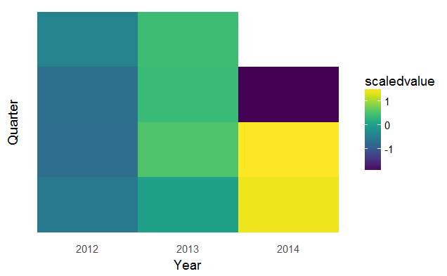

```r
library(ggthemes)
theme_heat <- theme_classic(14) +
    theme(axis.line = element_blank(),
          axis.ticks = element_blank())
vscale <- function(x) as.vector(scale(x))
df_new<-data.frame(sales$Year,sales$Quarter, sales$Revenue)
df_new_agg<-aggregate(df_new[,3],list(df_new[,2]),sum)
df_split<-data.frame(substr(df_new_agg$Group.1,4,7),substr(df_new_agg$Group.1,1,2),df_new_agg$x)
colnames(df_split) <- c("Year","Quarter", "Revenue")
#df_scaled<-data.frame(df_split,vscale(df_split$Revenue))
scaledvalue=vscale(df_split$Revenue)
g <- ggplot(df_split, aes(Year, Quarter, fill = scaledvalue)) +
    geom_tile() +
    scale_fill_viridis() + theme_heat +
    theme(axis.text.y = element_blank())
g
```

From the graph,we can learn that the revenue increases as each quarter passes by. But the last quarter (2014 Q3) has a large drop, maybe because the quarter doesn’t end when the statistic is carried out.

Q3: Missing values [20 points] Use the techniques in Chap. 9 (to be discussed in class) to visually explore patterns of missing data in the College Scorecard Data found here: https://collegescorecard.ed.gov/data/ Do not choose the large green “download all data” button but rather, the first choice under “featured downloads”: Scorecard data 5 MB CSV (7703 rows x 122 columns) Sample and/or subset as you wish. Include 3 graphs that show missing patterns. Describe the patterns you see. Choose the missing data patterns of a single variable (or single group of variables) to discuss in more detail, drawing on insight gleaned from the documentation, in addition to the graphs. Discuss possible causes for the missing data patterns, and potential biases which might result from these patterns. The documentation is available here: https://collegescorecard.ed.gov/assets/FullDataDocumentation.pdf Answer:

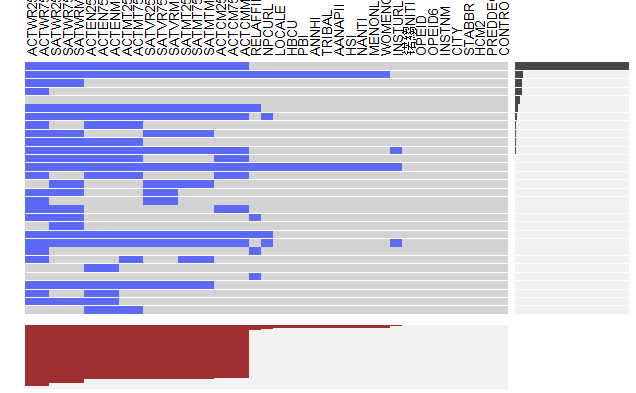

```r
library(extracat)
scorecard <- read.csv ("Most-Recent-Cohorts-Scorecard-Elements.csv")
is.na(scorecard) <- scorecard == "NULL"
part1 = scorecard[,c(1:41)]
visna(part1, sort="b")
```

From the graph, we can find that there’re many SAT and ACT score missing.

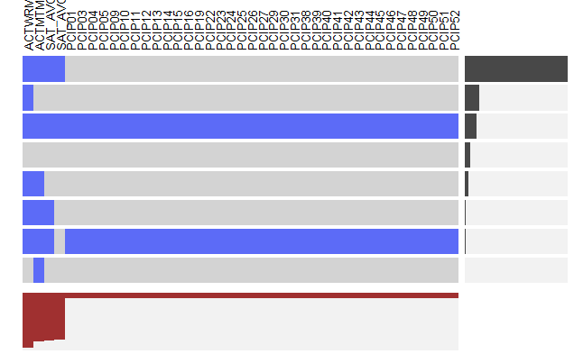

```r
part2 = scorecard[,c(42:82)]
visna(part2, sort="b")
```

From above graph, almost there’s no missing data in PCIP. It’s the pecentage of . degrees awarded in each two-digit CIP code field of study.

[output not shown]

[figure not shown]

```r
scorecard_ordered <-reorder(scorecard$INSTNM, scorecard$SATVR25 , function(x) sum(is.na(x)))
fluctile(xtabs(is.na(scorecard$SATVR25) ~ scorecard$INSTNM + scorecard$DISTANCEONLY, data=scorecard))
```

Many non distance school miss SATVR25